# R markdown 보고서

김홍식

2025-02-04

## 변수 설명

wage = 임금 : 월임금총액(단위:천 원). 정액급여+초과급여+전년도연간특별급여를 12로 나눔

experience = 평균 근속년수 : 근로자가 현 사업체에 입사한 날로부터 조사대상 기준일까지 근무한 기간을 말함

edu = 학력 : 중졸이하 9, 고졸 12, 전문대졸 14, 대졸이상 16

female = 성별 : 여자 1, 남자 0

old = 나이 : 평균연령

## Q-Q plot, 선형회귀분석

y = 임금, x = experience, edu, female, old

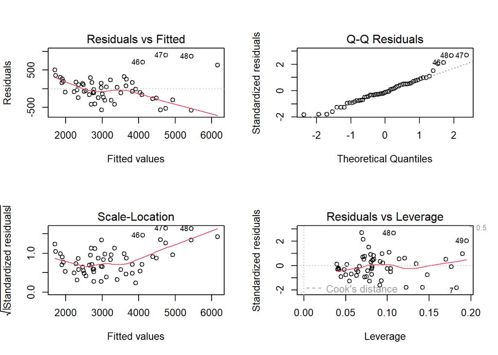

```
##
## Call:
## lm(formula = wage ~ experience + edu + female + old, data = final_data)
##
## Residuals:
##     Min      1Q  Median      3Q     Max
## -581.63 -237.40  -43.72  168.70  898.13
##
## Coefficients:
##             Estimate Std. Error t value Pr(>|t|)
## (Intercept)  1525.76     394.45   3.868 0.000312 ***
## experience    313.54      33.48   9.366 1.15e-12 ***
## edu           127.86      19.80   6.458 3.91e-08 ***
## female       -544.14     105.68  -5.149 4.25e-06 ***
## old           -37.08      10.79  -3.435 0.001185 **
## ---
## Signif. codes:  0 '***' 0.001 '**' 0.01 '*' 0.05 '.' 0.1 ' ' 1
##
## Residual standard error: 346.5 on 51 degrees of freedom
## Multiple R-squared:  0.9028, Adjusted R-squared:  0.8952
## F-statistic: 118.5 on 4 and 51 DF,  p-value: < 2.2e-16
```

## 임금과 나이

```
##
## Call:
## lm(formula = wage ~ old, data = final_data)
##
## Residuals:
##      Min       1Q   Median       3Q      Max
## -1865.15  -356.24   -60.54   389.47  2790.42
##
## Coefficients:
##             Estimate Std. Error t value Pr(>|t|)
## (Intercept)  1204.00     489.02   2.462    0.017 *
## old            53.94      12.73   4.237  8.9e-05 ***
## ---
## Signif. codes:  0 '***' 0.001 '**' 0.01 '*' 0.05 '.' 0.1 ' ' 1
##
## Residual standard error: 935.9 on 54 degrees of freedom
## Multiple R-squared:  0.2495, Adjusted R-squared:  0.2356
## F-statistic: 17.95 on 1 and 54 DF,  p-value: 8.898e-05
```

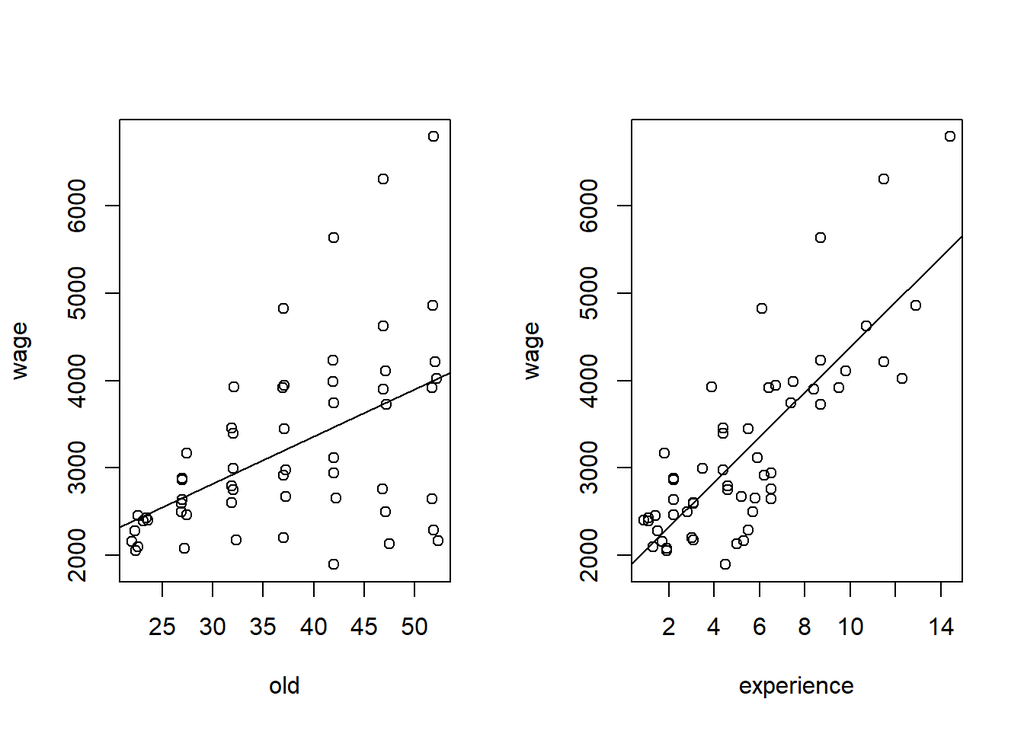

```
##
## Call:
## lm(formula = wage ~ experience, data = final_data)
##
## Residuals:
##      Min       1Q   Median       3Q      Max
## -1077.26  -393.14   -28.05   309.27  1587.65
##
## Coefficients:
##             Estimate Std. Error t value Pr(>|t|)
## (Intercept)   1808.8      162.8   11.11 1.44e-15 ***
## experience     257.9       25.6   10.07 5.30e-14 ***
## ---
## Signif. codes:  0 '***' 0.001 '**' 0.01 '*' 0.05 '.' 0.1 ' ' 1
##
## Residual standard error: 636.7 on 54 degrees of freedom
## Multiple R-squared:  0.6526, Adjusted R-squared:  0.6462
## F-statistic: 101.5 on 1 and 54 DF,  p-value: 5.296e-14
```

## old와 experience의 상관관계 0.85

```
## [1] 0.8578009
```

```
##
## Call:
## lm(formula = wage ~ experience + old + female, data = final_data)
##
## Residuals:
##     Min      1Q  Median      3Q     Max
## -1210.1  -240.6  -109.0   178.4  1212.0
##
## Coefficients:
##             Estimate Std. Error t value Pr(>|t|)
## (Intercept)  3581.76     310.93  11.519 6.29e-16 ***
## experience    405.82      40.42  10.040 9.05e-14 ***
## old           -63.91      13.30  -4.805 1.36e-05 ***
## female       -403.77     138.09  -2.924  0.00511 **
## ---
## Signif. codes:  0 '***' 0.001 '**' 0.01 '*' 0.05 '.' 0.1 ' ' 1
##
## Residual standard error: 462.6 on 52 degrees of freedom
## Multiple R-squared:  0.8234, Adjusted R-squared:  0.8132
## F-statistic: 80.82 on 3 and 52 DF,  p-value: < 2.2e-16
```

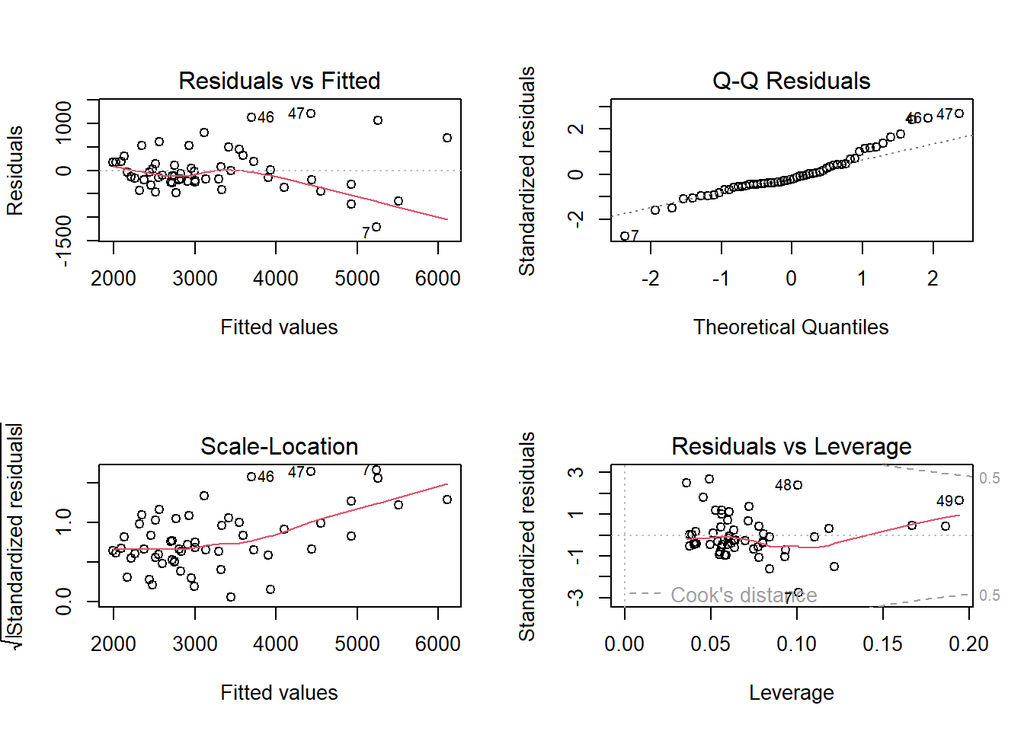

고졸남자 = 2134.503*** + 151.298***∙exper + 214.096 + 22.533∙exper

전문대졸남자 = 2134.503*** + 151.298*** ∙exper + 302.234* + 48.859*∙exper

대졸이상남자 = 2134.503*** + 151.298*** ∙exper + 582.443*** + 152.996***∙exper

중졸이하여자 = 2134.503*** - 475.061*** + 151.298***∙exper

고졸여자 = 2134.503*** - 475.061*** + 151.298***∙exper + 214.096 + 22.533∙exper – 38.661∙exper

전문대졸여자 = 2134.503*** - 475.061*** + 151.298*** ∙exper + 302.234* + 48.859** ∙exper – 60.224**∙exper

대졸이상여자 =2134.503*** - 475.061*** + 151.298*** ∙exper + 582.443*** + 152.996*** ∙exper – 90.040***∙exper

## 남녀가 동일한 조건일 때 임금 차이 추정

대졸이상남자 = 2134.503*** + 151.298*** ∙exper + 582.443*** + 152.996***∙exper

대졸이상여자 =2134.503*** - 475.061*** + 151.298*** ∙exper + 582.443*** + 152.996∙exper – 90.040***∙exper

### 평균근속년수(exper) = 10일경우

#### 대졸이상남자= 2716.946 + 304.294∙exper = 5759.886 = **월 575만원**

#### 대졸이상여자= 2241.885 + 214.254∙exper = 4384.425 = **월 438만원**

## 데이터 시각화

### 남성과 여성, 임금과 평균근속년수의 관계

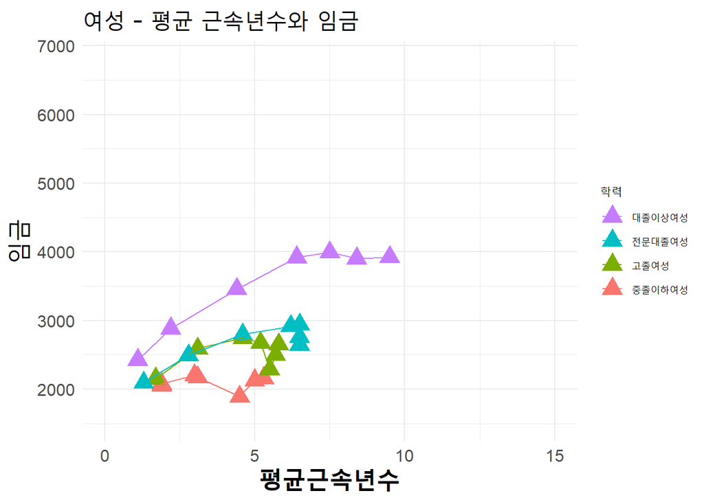

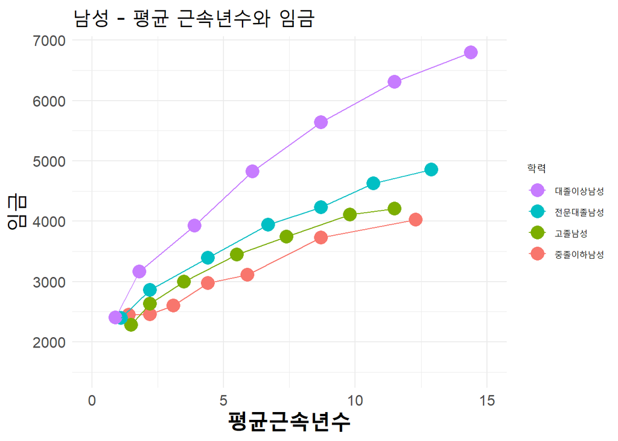

### 남성과 여성, 나이와 임금의 관계

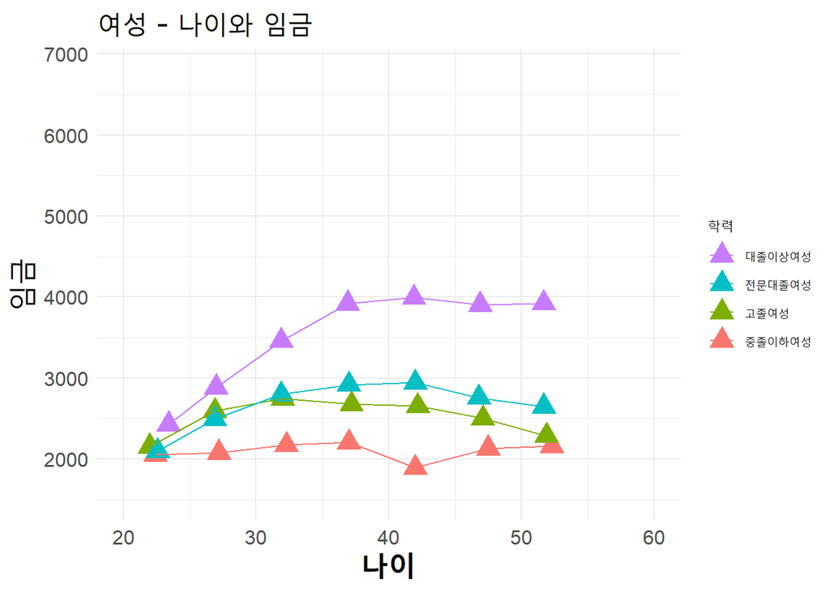

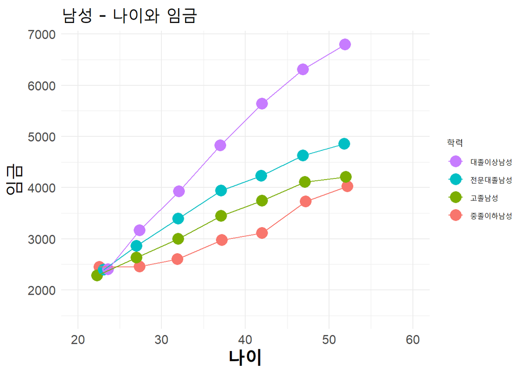

## Boxplot

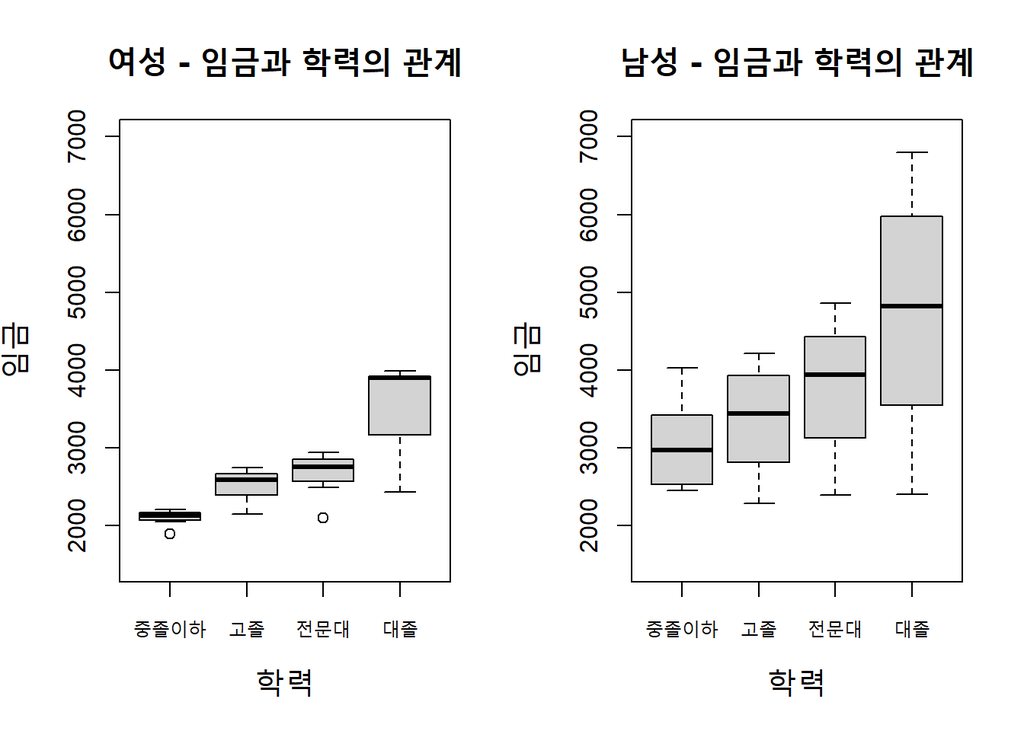

### 여성이 남성에 비해 나이와 근속년수가 비례하지 않는 모습을 보임

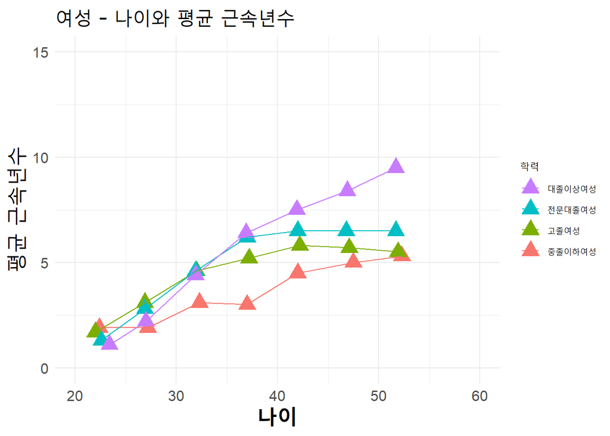

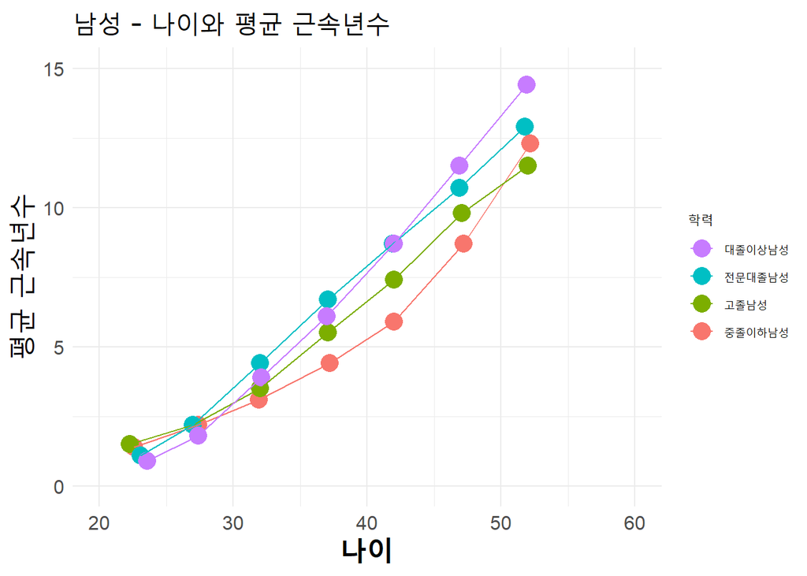

#### 여자 - 나이와 근속년수 상관관계 0.83

```
## [1] 0.8308853
```

#### 남자 - 나이와 근속년수 상관관계 0.97

```
## [1] 0.9708377
```

### 남자가 여자보다 나이에 비해 근속년수가 길다

### 특히 여성이 30대가 될 때 근속년수가 꺾이는 경력단절 현상이 관찰됨

## 3D plot

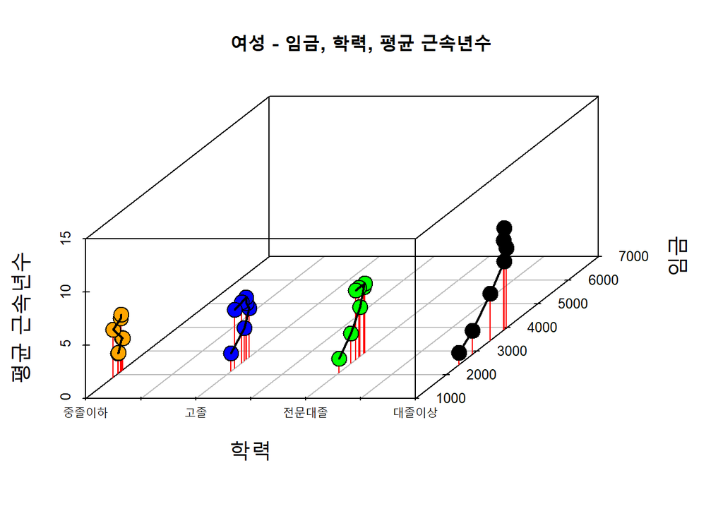

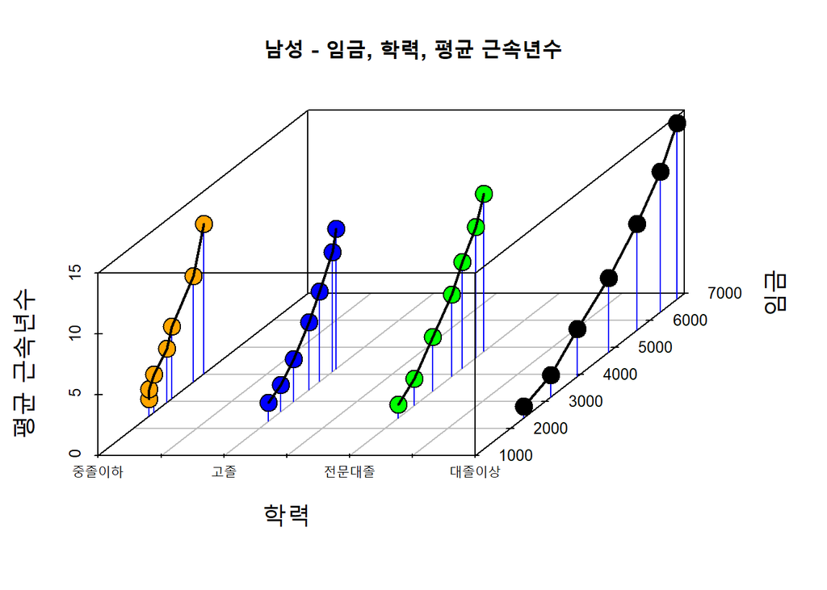